# BADAS: Part IV

`ggplot2`

Robin Genuer, Loïc Ferrer & Boris Hejblum

June 17<sup>th</sup>, 2019

# Introduction

Ce document donne quelques éléments introductifs sur l’utilisation du package `ggplot2`.

## Le package `ggplot2`

`ggplot2` est un package de plus en plus utilisé pour tracer des graphiques sur R. La syntaxe est différente des fonctions graphiques de base, mais s’avère très puissante en pratique. Une très bonne référence pour commencer à utiliser ce package se trouve [ici](http://www.cookbook-r.com/Graphs/). L’[aide en ligne](http://docs.ggplot2.org/current/) est plus complète (mais très fournie). On pourra également se reporter à cet [aide-mémoire](https://www.rstudio.com/wp-content/uploads/2015/06/ggplot2-french.pdf)

Installer le package puis le charger.

```r
# install.packages('ggplot2')
library(ggplot2)
```

Importer ensuite le jeu de données `naissance.txt` documentant le poids à la naissance de 189 nouveaux-nés en fonctions d’un certains nombres de variable (dont l’âge de la mère, son poids ainsi que l’historique d’hypertension), puis transformer la variable `SMOKE` pour illustrer le codage “Non-Fumeur” (codé `0`) et “Fumeur” (codé `1`), ainsi que la variable `HT` codée “Non” (`0`) et “Oui” (`1`).

```r
naissance <- read.delim("naissance.txt")
naissance <- transform(naissance,
    SMOKE = factor(SMOKE, labels = c("Non-Fumeur", "Fumeur")),
    HT = factor(HT, labels = c("Non", "Oui")))
str(naissance)
```

```
## 'data.frame':    189 obs. of  10 variables:
##  $ ID   : int  85 86 87 88 89 91 92 93 94 95 ...
##  $ AGE  : int  19 33 20 21 18 21 22 17 29 26 ...
##  $ LWT  : int  182 155 105 108 107 124 118 103 123 113 ...
##  $ RACE : int  2 3 1 1 1 3 1 3 1 1 ...
##  $ SMOKE: Factor w/ 2 levels "Non-Fumeur","Fumeur": 1 1 2 2 2 1 1 1 2 2 ...
##  $ PTL  : int  0 0 0 0 0 0 0 0 0 0 ...
##  $ HT   : Factor w/ 2 levels "Non","Oui": 1 1 1 1 1 1 1 1 1 1 ...
##  $ UI   : int  1 0 0 1 1 0 0 0 0 0 ...
##  $ FVT  : int  0 3 1 2 0 0 1 1 1 0 ...
##  $ BWT  : int  2523 2551 2557 2594 2600 2622 2637 2637 2663 2665 ...
```

## La fonction `ggplot()`

`ggplot2` fonctionne par un système de couches (“layers”). Ce système permet de rajouter des couches avec `+`.

La fonction principale du package `ggplot2` est la fonction `ggplot()`. À cette fonction, qui a pour but de spécifier et de préparer les données pour le graphique, on ajoute donc des couches grâce aux fonctions `geom_...()`, qui vont spécifier le type de graphique à afficher (par exemple `geom_point()` ou `geom_bar()`).

De plus, `ggplot2` permet de rajouter des couches à des graphiques déjà existants sauvegardés dans des objets. C’est un comportement très différent de la gestion des graphiques comparé au `R` de base.

# Nuage de points

### Exercice 1 :

1. Tracer le nuage de point du poids à la naissance (variable `BWT`) en fonction de l’âge (variable `AGE`) grâce à la fonction `geom_point()`.
2. Ajouter une couleur selon le statut tabagique de la mère (`SMOKE`) (*on remarque que la légende se trace automatiquement*).
3. Rajouter une droite de régression avec la fonction `geom_smooth()`.
4. Consulter l’aide de la fonction `geom_smooth()` pour enlever l’intervalle de confiance et tracer la droite en rouge.
5. A l’aide de `geom_hline()`, ajouter une droite horizontale d’ordonnée 2500, bleue et de style “tirets”.
6. Créer un objet `p` qui contient le graphique du nuage de points uniquement comme demandé à la question 1 (taper le nom de l’objet pour vérifier que le graphique a été correctement créé.). Rajouter ensuite la droite de régression en modifiant `p`.
7. Préciser le nom des axes.
8. Ajouter le thème `theme_bw()` afin de se rapprocher d’un style plus classique de graphique.

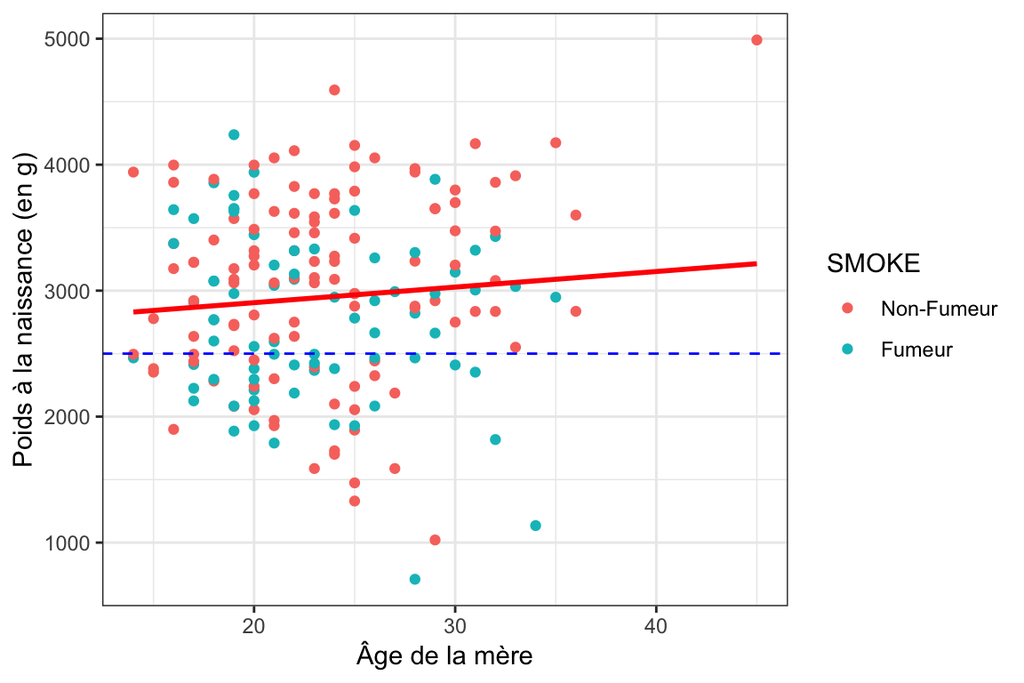

```r
ggplot(naissance, aes(x = AGE, y = BWT)) + geom_point(aes(color = SMOKE)) +
    geom_smooth(method = lm, se = FALSE, colour = "red") + geom_hline(aes(yintercept = 2500),
    colour = "blue", linetype = "dashed") + theme_bw() + ylab("Poids à la naissance (en g)") +
    xlab("Âge de la mère")
```

# Stratification

Le package `ggplot2` rend très facile la stratification des représentations selon des groupes définis par une variable catégorielle.

### Exercice 2 :

1. Reproduire le graphique précédent en traçant 2 droites de regression selon le statut tabagique de la mère (en introduisant l’estéthique `group`dans la fonction `aes()` de la fonction `geom_smooth()`).

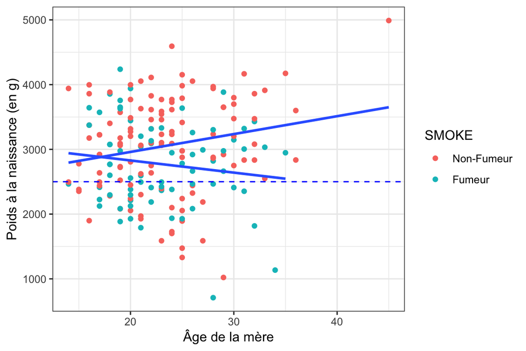

```r
ggplot(naissance, aes(x = AGE, y = BWT)) + geom_point(aes(color = SMOKE)) +
    geom_smooth(method = lm, se = FALSE, aes(group = SMOKE)) + geom_hline(aes(yintercept = 2500),
    colour = "blue", linetype = "dashed") + theme_bw() + ylab("Poids à la naissance (en g)") +
    xlab("Âge de la mère")
```

2. Utiliser la fonction `facet_wrap()` pour tracer 2 graphiques distincts.
3. Laisser l’échelle s’adapter à chacun des 2 graphiques.

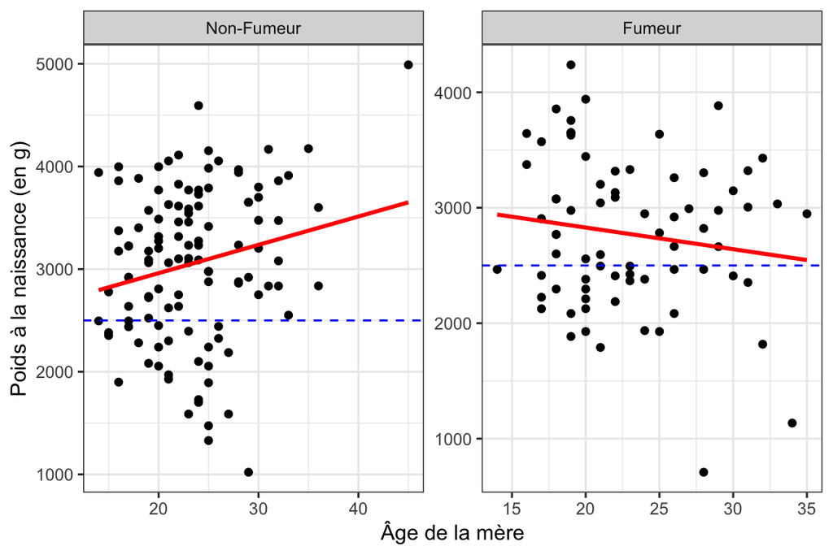

```r
ggplot(naissance, aes(x = AGE, y = BWT)) + geom_point() + geom_smooth(method = lm,
    se = FALSE, colour = "red") + geom_hline(aes(yintercept = 2500), colour = "blue",
    linetype = "dashed") + theme_bw() + ylab("Poids à la naissance (en g)") +
    xlab("Âge de la mère") + facet_wrap(~SMOKE, scales = "free")
```

# Autres types de graphiques

### Exercice 3 :

1. Tracer un boxplot du poids du bébé à la naissance (on utilisera `x=""` dans les esthétiques de `geom_boxplot()`).

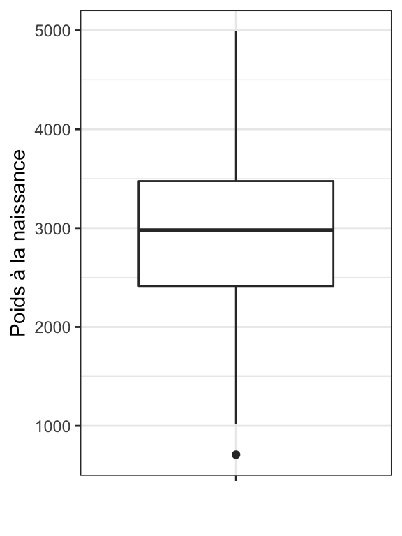

```r
ggplot(naissance) + geom_boxplot(aes(x = "", y = BWT)) + theme_bw() + ylab("Poids à la naissance") +
    xlab("")
```

2. Stratifier selon le statut fumeur de la mère (on pourra s’intéresser à l’esthétique `fill`).
3. Ajouter un titre avec la fonction `ggtitle()`.

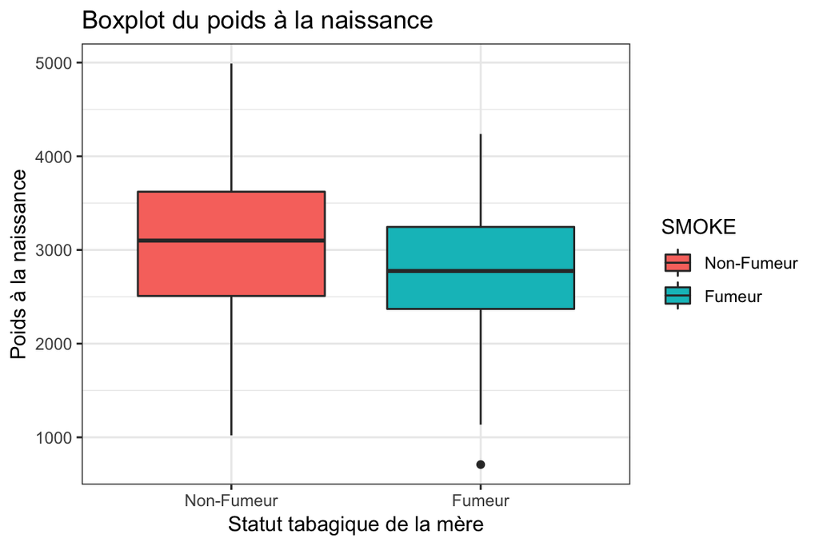

```r
ggplot(naissance) + geom_boxplot(aes(x = SMOKE, y = BWT, fill = SMOKE)) + theme_bw() +
    ylab("Poids à la naissance") + xlab("Statut tabagique de la mère") + ggtitle("Boxplot du poids à la naissance")
```

4. Tracer un histogramme du poids à la naissance avec la fonction `geom_histogram()`. Ajouter un contour blanc pour une meilleure lisibilité. Ajouter une ligne verticale indiquant la limite inférieure de 2,5 kg.

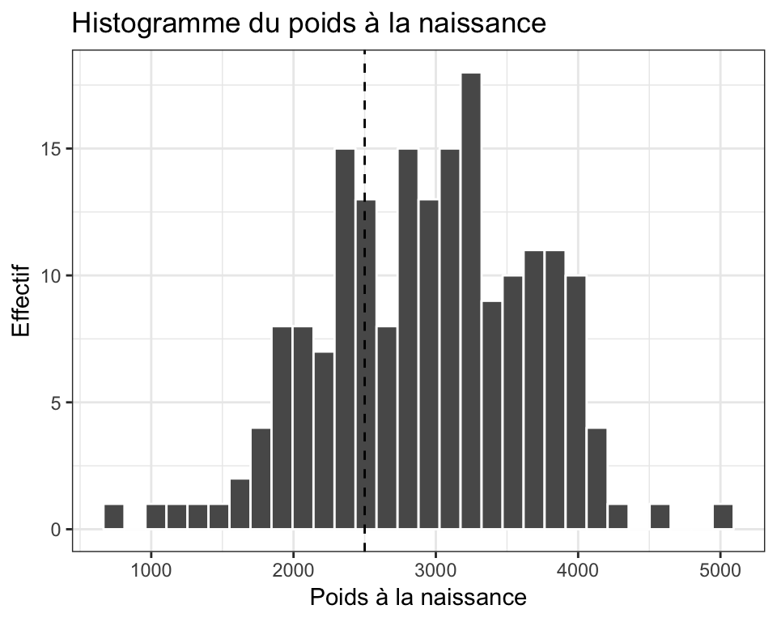

```r
ggplot(naissance) + geom_histogram(aes(x = BWT), color = "white") + geom_vline(aes(xintercept = 2500),
    colour = "black", linetype = "dashed") + theme_bw() + xlab("Poids à la naissance") +
    ylab("Effectif") + ggtitle("Histogramme du poids à la naissance")
```

5. Remplir les barres de l’histogramme selon l’historique d’hypertension.
6. Changer le code couleur grâce à la fonction `scale_fill_manual()`.

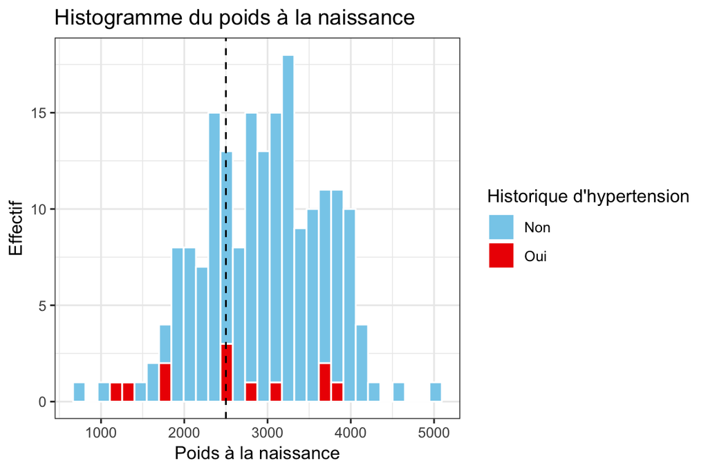

```r
ggplot(naissance) + geom_histogram(aes(x = BWT, fill = HT), color = "white") +
    geom_vline(aes(xintercept = 2500), colour = "black", linetype = "dashed") +
    theme_bw() + xlab("Poids à la naissance") + ylab("Effectif") + ggtitle("Histogramme du poids à la naissance") +
    scale_fill_manual("Historique d'hypertension", values = c("skyblue", "red2"))
```

7. Tracer une estimation de la densité de probabilité du poids à la naissance, dans chaque groupe de statut tabagique (sur le même graphique) avec la fonction `geom_density()`.

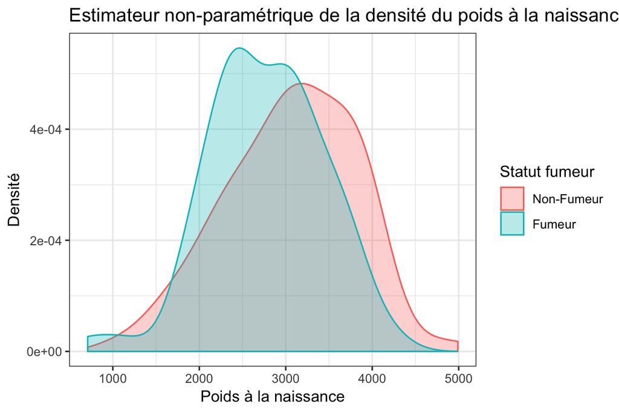

```r
ggplot(naissance) + geom_density(aes(x = BWT, fill = SMOKE, color = SMOKE),
    alpha = 0.3) + theme_bw() + xlab("Poids à la naissance") + ylab("Densité") +
    ggtitle("Estimateur non-paramétrique de la densité du poids à la naissance") +
    scale_fill_discrete("Statut fumeur") + scale_color_discrete("Statut fumeur")
```

8. Passer à l’échelle logarithmique avec la fonction `scale_x_log10()`.
9. Exporter le graphique au fromat *.pdf* avec la fonction `ggsave()`.
10. Ajouter une ligne verticale indiquant la limite inférieure de 2,5 kg, puis ajouter une légende pour la ligne verticale.

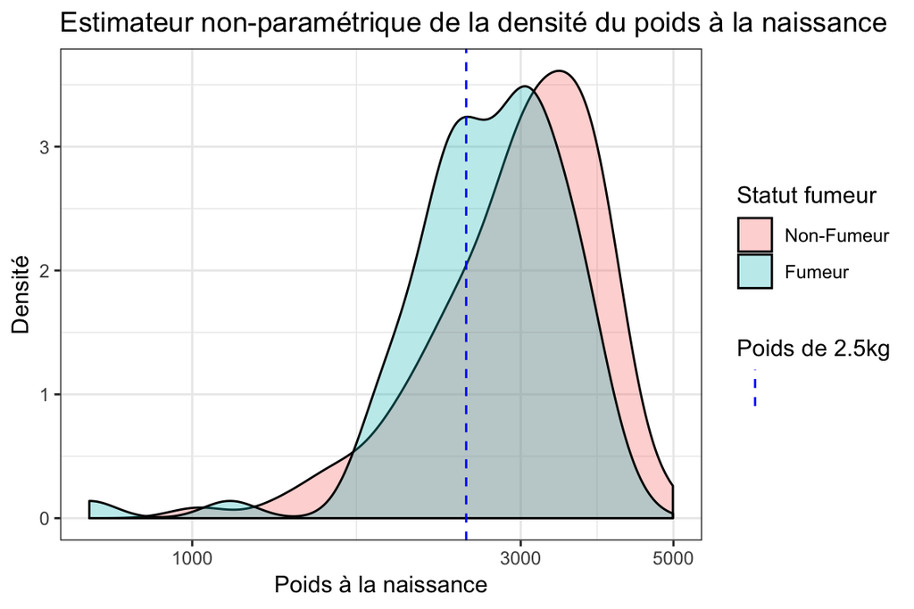

```r
ggplot(naissance) + geom_density(aes(x = BWT, fill = SMOKE), alpha = 0.3) +
    geom_vline(aes(xintercept = 2500, linetype = "dashed"), colour = "blue") +
    theme_bw() + xlab("Poids à la naissance") + ylab("Densité") + ggtitle("Estimateur non-paramétrique de la densité du poids à la naissance") +
    scale_fill_discrete("Statut fumeur") + scale_x_log10() + scale_linetype_manual(values = "dashed",
    name = "Poids de 2.5kg", labels = "")
```